# 01_Access_To_Healthcare

# Data Preparation Report: Access to Healthcare Dataset

```r
# Data manipulation and cleaning
library(dplyr)
library(tidyr)
library(stringr)
library(readr)
library(here)
```

```r
# Data visualization
library(ggplot2)
library(visdat) # For missing data visualization
library(skimr)  # For detailed summaries
library(naniar)
library(DT)
library(knitr)
```

```r
acc_df <- read.csv(here("data","raw","access-to-health-care_national_zaf.csv"))

# Remove metadata row if present
acc_df <- acc_df[-1, ]
rownames(acc_df) <- NULL

cat("Dataset loaded successfully.\n")
```

```
## Dataset loaded successfully.
```

**Explanation**: We load the dataset and remove the first row, which contains metadata rather than actual observations.

## 2. Initial Data Assessment

### 2.1 First Look

```r
# Display first few rows and structure
head(acc_df, 5)
```

```
##   ISO3 DataId                              Indicator Value Precision
## 1  ZAF 751751        Antenatal care provider: Doctor  28.5         1
## 2  ZAF 567476        Antenatal care provider: Doctor    30         1
## 3  ZAF 205488        Antenatal care provider: Doctor  27.3         1
## 4  ZAF 751748 Antenatal care provider: Nurse/midwife  66.6         1
## 5  ZAF 567472 Antenatal care provider: Nurse/midwife    65         1
##   DHS_CountryCode  CountryName SurveyYear  SurveyId   IndicatorId
## 1              ZA South Africa       1998 ZA1998DHS RH_ANCP_W_DOC
## 2              ZA South Africa       1998 ZA1998DHS RH_ANCP_W_DOC
## 3              ZA South Africa       1998 ZA1998DHS RH_ANCP_W_DOC
## 4              ZA South Africa       1998 ZA1998DHS RH_ANCP_W_NRS
## 5              ZA South Africa       1998 ZA1998DHS RH_ANCP_W_NRS
##   IndicatorOrder IndicatorType CharacteristicId CharacteristicOrder
## 1       83363010             I             1000                   0
## 2       83363010             I             1000                   0
```

[output cut: 27 more lines]

### 2.2 Data Structure

```r
skim(acc_df)
```

Data summary

| Name | acc_df |
| --- | --- |
| Number of rows | 275 |
| Number of columns | 29 |
| _______________________ |  |
| Column type frequency: |  |
| character | 17 |
| logical | 4 |
| numeric | 8 |
| ________________________ |  |
| Group variables | None |

**Variable type: character**

| skim_variable | n_missing | complete_rate | min | max | empty | n_unique | whitespace |
| --- | --- | --- | --- | --- | --- | --- | --- |
| ISO3 | 0 | 1 | 3 | 3 | 0 | 1 | 0 |
| DataId | 0 | 1 | 4 | 6 | 0 | 275 | 0 |
| Indicator | 0 | 1 | 17 | 100 | 0 | 68 | 0 |
| Value | 0 | 1 | 1 | 4 | 0 | 190 | 0 |
| Precision | 0 | 1 | 1 | 1 | 0 | 2 | 0 |
| DHS_CountryCode | 0 | 1 | 2 | 2 | 0 | 1 | 0 |
| CountryName | 0 | 1 | 12 | 12 | 0 | 1 | 0 |
| SurveyYear | 0 | 1 | 4 | 4 | 0 | 2 | 0 |
| SurveyId | 0 | 1 | 9 | 9 | 0 | 2 | 0 |
| IndicatorId | 0 | 1 | 13 | 13 | 0 | 72 | 0 |
| IndicatorType | 0 | 1 | 1 | 1 | 0 | 5 | 0 |
| CharacteristicCategory | 0 | 1 | 5 | 5 | 0 | 1 | 0 |
| CharacteristicLabel | 0 | 1 | 5 | 5 | 0 | 1 | 0 |
| ByVariableId | 0 | 1 | 1 | 5 | 0 | 4 | 0 |
| ByVariableLabel | 0 | 1 | 0 | 32 | 13 | 4 | 0 |
| SDRID | 0 | 1 | 10 | 10 | 0 | 72 | 0 |
| SurveyType | 0 | 1 | 3 | 3 | 0 | 1 | 0 |

**Variable type: logical**

| skim_variable | n_missing | complete_rate | mean | count |
| --- | --- | --- | --- | --- |
| RegionId | 275 | 0 | NaN | : |
| CILow | 275 | 0 | NaN | : |
| CIHigh | 275 | 0 | NaN | : |
| LevelRank | 275 | 0 | NaN | : |

**Variable type: numeric**

| skim_variable | n_missing | complete_rate | mean | sd | p0 | p25 | p50 | p75 | p100 | hist |
| --- | --- | --- | --- | --- | --- | --- | --- | --- | --- | --- |
| IndicatorOrder | 0 | 1.00 | 87126424.21 | 5002220.64 | 83363010 | 83566030 | 83606090 | 93966070 | 94096170 | ▇▁▁▁▅ |
| CharacteristicId | 0 | 1.00 | 1000.00 | 0.00 | 1000 | 1000 | 1000 | 1000 | 1000 | ▁▁▇▁▁ |
| CharacteristicOrder | 0 | 1.00 | 0.00 | 0.00 | 0 | 0 | 0 | 0 | 0 | ▁▁▇▁▁ |
| IsTotal | 0 | 1.00 | 1.00 | 0.00 | 1 | 1 | 1 | 1 | 1 | ▁▁▇▁▁ |
| IsPreferred | 0 | 1.00 | 0.42 | 0.49 | 0 | 0 | 0 | 1 | 1 | ▇▁▁▁▆ |
| SurveyYearLabel | 0 | 1.00 | 2007.62 | 8.99 | 1998 | 1998 | 2016 | 2016 | 2016 | ▇▁▁▁▇ |
| DenominatorWeighted | 34 | 0.88 | 2048.65 | 1428.93 | 68 | 627 | 2010 | 3072 | 4992 | ▇▆▅▅▃ |
| DenominatorUnweighted | 34 | 0.88 | 2062.17 | 1445.14 | 59 | 634 | 2041 | 3119 | 5066 | ▇▆▆▃▃ |

```r
glimpse(acc_df)
```

```
## Rows: 275
## Columns: 29
## $ ISO3                   <chr> "ZAF", "ZAF", "ZAF", "ZAF", "ZAF", "ZAF", "ZAF"…
## $ DataId                 <chr> "751751", "567476", "205488", "751748", "567472…
## $ Indicator              <chr> "Antenatal care provider: Doctor", "Antenatal c…
## $ Value                  <chr> "28.5", "30", "27.3", "66.6", "65", "68.4", "0.…
## $ Precision              <chr> "1", "1", "1", "1", "1", "1", "1", "1", "1", "1…
## $ DHS_CountryCode        <chr> "ZA", "ZA", "ZA", "ZA", "ZA", "ZA", "ZA", "ZA",…
## $ CountryName            <chr> "South Africa", "South Africa", "South Africa",…
## $ SurveyYear             <chr> "1998", "1998", "1998", "1998", "1998", "1998",…
## $ SurveyId               <chr> "ZA1998DHS", "ZA1998DHS", "ZA1998DHS", "ZA1998D…
## $ IndicatorId            <chr> "RH_ANCP_W_DOC", "RH_ANCP_W_DOC", "RH_ANCP_W_DO…
## $ IndicatorOrder         <int> 83363010, 83363010, 83363010, 83363020, 8336302…
## $ IndicatorType          <chr> "I", "I", "I", "I", "I", "I", "I", "I", "I", "I…
## $ CharacteristicId       <int> 1000, 1000, 1000, 1000, 1000, 1000, 1000, 1000,…
```

[output cut: 16 more lines]

### 2.3 Visualize Missing Data

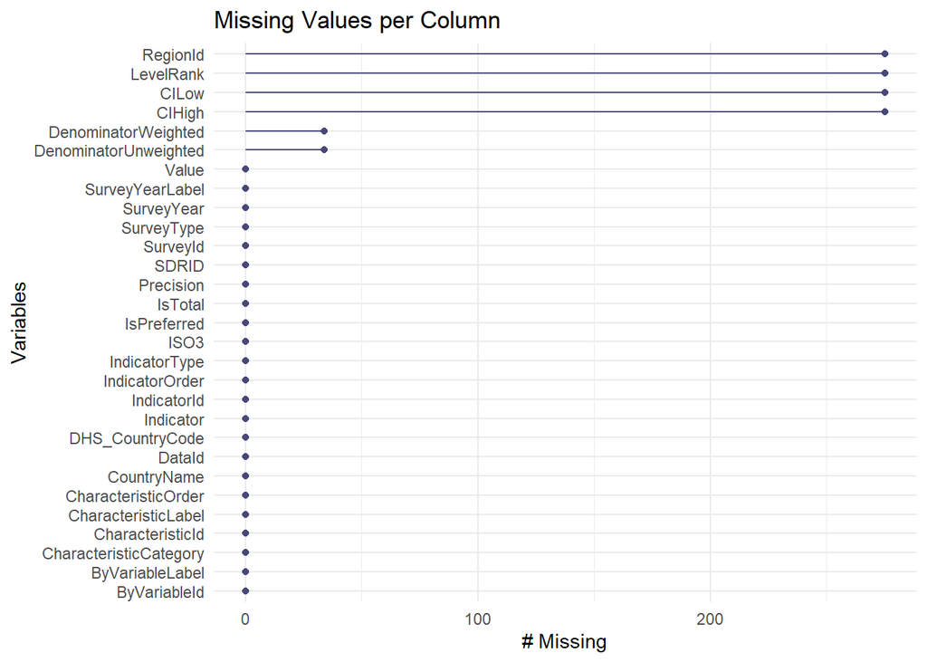

```r
gg_miss_var(acc_df) + ggtitle("Missing Values per Column")
```

**Purpose:**  
Understand the dataset’s structure, content, and initial quality.

**What the Code Does:**  
- Displays the first few rows with `head()`.  
- Uses `skim()` for comprehensive summary statistics and data quality indicators.  
- Visualizes missing values with `gg_miss_var()` to spot columns needing attention.

**Result:**  
- Provides a snapshot of the data structure, missingness, and variable types.  
- Helps plan cleaning steps such as type conversion and missing value treatment.

**Why it matters:**  
- Early insight prevents errors later in cleaning and ensures informed preprocessing decisions.

## 3. Data Cleaning Process

### 3.1 Handle Duplicates

```r
# Check for exact duplicates
duplicate_count <- sum(duplicated(acc_df))
cat("Number of exact duplicate rows:", duplicate_count, "\n")
```

```
## Number of exact duplicate rows: 0
```

**Purpose:**  
Eliminate repeated rows that could distort calculations or summaries.

**Outcome / Result:**  
- Dataset contains only unique records.

**Relevance / Why it matters:**  
- Prevents overcounting or bias in statistics and visualizations

### 3.2 Convert Data Types

```r
# Explicitly only select columns that exist
numeric_cols <- c("Value", "Precision", "DenominatorWeighted", "DenominatorUnweighted")
integer_cols <- c("SurveyYear", "IndicatorOrder", "CharacteristicOrder", "SurveyYearLabel", "RegionId")
id_cols <- c("CharacteristicId", "ByVariableId")
logical_cols <- c("IsTotal", "IsPreferred")

acc_df <- acc_df %>%
  mutate(across(any_of(numeric_cols), as.numeric)) %>%
  mutate(across(any_of(integer_cols), as.integer)) %>%
  mutate(across(any_of(id_cols), as.character)) %>%
  mutate(across(any_of(logical_cols), ~as.logical(as.integer(.)))) %>%
  mutate(across(where(is.character), str_trim))

cat("Data types converted successfully.\n")
```

```
## Data types converted successfully.
```

```r
glimpse(acc_df)
```

```
## Rows: 275
## Columns: 29
## $ ISO3                   <chr> "ZAF", "ZAF", "ZAF", "ZAF", "ZAF", "ZAF", "ZAF"…
## $ DataId                 <chr> "751751", "567476", "205488", "751748", "567472…
## $ Indicator              <chr> "Antenatal care provider: Doctor", "Antenatal c…
## $ Value                  <dbl> 28.5, 30.0, 27.3, 66.6, 65.0, 68.4, 0.1, 0.1, 0…
## $ Precision              <dbl> 1, 1, 1, 1, 1, 1, 1, 1, 1, 1, 1, 1, 1, 1, 1, 1,…
## $ DHS_CountryCode        <chr> "ZA", "ZA", "ZA", "ZA", "ZA", "ZA", "ZA", "ZA",…
## $ CountryName            <chr> "South Africa", "South Africa", "South Africa",…
## $ SurveyYear             <int> 1998, 1998, 1998, 1998, 1998, 1998, 1998, 1998,…
## $ SurveyId               <chr> "ZA1998DHS", "ZA1998DHS", "ZA1998DHS", "ZA1998D…
## $ IndicatorId            <chr> "RH_ANCP_W_DOC", "RH_ANCP_W_DOC", "RH_ANCP_W_DO…
## $ IndicatorOrder         <int> 83363010, 83363010, 83363010, 83363020, 8336302…
## $ IndicatorType          <chr> "I", "I", "I", "I", "I", "I", "I", "I", "I", "I…
## $ CharacteristicId       <chr> "1000", "1000", "1000", "1000", "1000", "1000",…
```

[output cut: 16 more lines]

**Purpose:** Ensure that each column in the dataset has the **correct data type** so that subsequent analysis and calculations work as expected. Wrong data types (e.g., numbers stored as text) can lead to errors or incorrect results.

**What the code does:**

1. **Define column groups**:
   - `numeric_cols` → Columns that store measurements or continuous values (e.g., `Value`, `Precision`).
   - `integer_cols` → Columns representing whole numbers, IDs, or survey codes.
   - `id_cols` → Identifier columns stored as text (character) to avoid accidental math operations.
   - `logical_cols` → Columns representing true/false flags (`IsTotal`, `IsPreferred`).
2. **Convert columns using `mutate(across(...))`**:
   - `as.numeric` → Converts to numeric type for calculations.
   - `as.integer` → Converts to integers.
   - `as.character` → Converts IDs to text.
   - `as.logical(as.integer(.))` → Converts numeric 0/1 flags to TRUE/FALSE.
3. **Trim extra spaces in character columns**:
   - `str_trim` removes leading/trailing whitespace from text fields, preventing errors in grouping or filtering.
4. **Preview changes**:
   - `glimpse(acc_df)` shows updated column types and a quick snapshot of the data.

**Outcome:**

- All columns now have **consistent and correct data types**.
- Prevents errors in calculations, filtering, grouping, and plotting.
- Makes the dataset **analysis-ready**.

**Why it matters:**

- Clean, standardized data types are **foundational** before handling missing values, outliers, or doing any statistical modeling.

### 3.3 Handle Missing Values

```r
# Create missing value summary before treatment
missing_before <- colSums(is.na(acc_df))

# Strategy 1: Remove columns with excessive missingness (>80%)
high_missing_cols <- names(missing_before[missing_before > nrow(acc_df) * 0.8])
cat("Columns with >80% missing values:", paste(high_missing_cols, collapse = ", "), "\n")
```

```
## Columns with >80% missing values: RegionId, CILow, CIHigh, LevelRank
```

```r
# Strategy 2: Targeted imputation for specific columns

acc_df <- acc_df %>%
  arrange(SurveyYear, CharacteristicId) %>%
  group_by(Indicator, CharacteristicId) %>%
  fill(DenominatorWeighted, DenominatorUnweighted, .direction = "downup") %>%
  ungroup()

# Strategy 3: Remove rows with missing critical values
acc_df <- acc_df %>%
  filter(!is.na(Value), !is.na(Indicator))

missing_after <- colSums(is.na(acc_df))
cat("Missing values reduced significantly.\n")
```

```
## Missing values reduced significantly.
```

```r
acc_df <- acc_df %>%
  mutate(
    DenominatorWeighted = ifelse(is.na(DenominatorWeighted), median(DenominatorWeighted, na.rm = TRUE), DenominatorWeighted),
    DenominatorUnweighted = ifelse(is.na(DenominatorUnweighted), median(DenominatorUnweighted, na.rm = TRUE), DenominatorUnweighted)
  )
```

- **Identify missing data:** Count NAs in all columns to understand the scope of missingness.
- **Remove unhelpful columns:** Drop columns with more than 80% missing values.
- **Impute key numeric values:** Fill missing denominators using nearby values within groups (`down` and `up`) and replace remaining NAs with the median.
- **Remove incomplete rows:** Delete rows missing critical information (`Value` or `Indicator`).

**Result:** The dataset is **more complete, consistent, and ready for analysis**, with minimal risk of missing-value errors affecting results.

### 3.4 Remove Redundant Columns

```r
# Define redundant columns explicitly
redundant_cols <- c("ISO3", "DHS_CountryCode", "CountryName",
                    "SurveyId", "SurveyType")

# Combine with high-missing columns (if any)
cols_to_drop <- c(redundant_cols, high_missing_cols)

# Remove them safely
acc_df <- acc_df %>%
  select(-any_of(cols_to_drop))

cat("Redundant columns removed. New dimensions:", dim(acc_df), "\n")
```

```
## Redundant columns removed. New dimensions: 275 20
```

#### Remove Redundant Columns – Summary

- **Purpose:** Remove columns that are **not useful** for analysis or mostly empty.
- **What’s removed:** Metadata columns (like `ISO3`, `CountryName`, `SurveyId`) and any column with >80% missing values.
- **Result:** Dataset is **cleaner, smaller, and easier to work with**, containing only relevant and populated columns.

#### Why Certain Columns Were Removed

1. **Metadata columns (e.g., `ISO3`, `CountryName`, `SurveyId`, `SurveyType`, `DHS_CountryCode`)**
   - These columns **don’t provide new information** for analysis.
   - For example, `ISO3` and `CountryName` just identify the country—if all data is already for South Africa, they are redundant.
   - `SurveyId` and `SurveyType` are identifiers for surveys, not variables we analyze. Keeping them would **clutter the dataset**.
2. **Columns with >80% missing values**
   - Columns that are mostly empty **cannot be reliably analyzed**.
   - Imputing or filling them would introduce **too much uncertainty**.
   - Removing them keeps the dataset **focused on meaningful, populated data**.

**Bottom line:** These columns were removed to make the dataset **leaner, more focused, and analysis-ready**, preventing confusion or wasted effort on irrelevant or unreliable data.

[output not shown]

## 5. Save Cleaned Data

```r
# Ensure directory exists
if(!dir.exists(here("data", "processed"))) {
  dir.create(here("data", "processed"), recursive = TRUE)
}

# Save cleaned dataset
write_csv(acc_df, here("data", "processed", "healthcare_access_cleaned.csv"))
saveRDS(acc_df, here("data", "processed", "healthcare_access_cleaned.rds"))

cat("Cleaned data saved to data/processed/ directory.\n")
```

```
## Cleaned data saved to data/processed/ directory.
```

**Purpose:**  
Persist the cleaned dataset for reproducibility and later use.

**Method / What the Code Does:**  
- Saves as CSV and RDS in a `processed` folder.

**Outcome / Result:**  
- Cleaned dataset is safely stored for analysis or sharing.

**Relevance / Why it matters:**  
- Ensures reproducibility and prevents accidental data loss.